# R4DS - Data Vis

We can also do something like calculating the percent of total

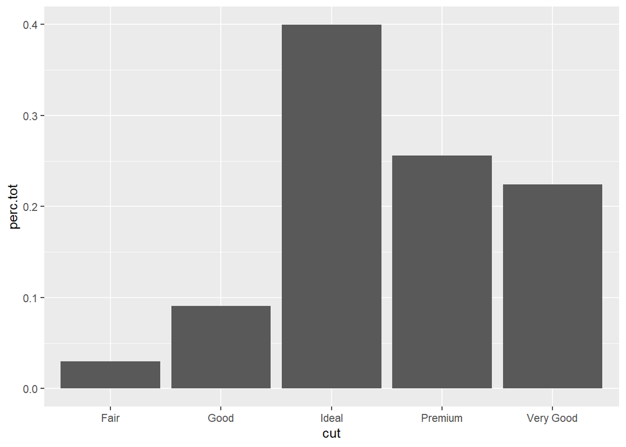

```r
tot <- sum(demo$freq)
demo$perc.tot <- demo$freq/tot

ggplot(data=demo) +
  geom_bar(mapping=aes(x=cut, y=perc.tot), stat="identity")
```

You can do a similar kind of thing using the diamonds dataset except without the explicit calculation.

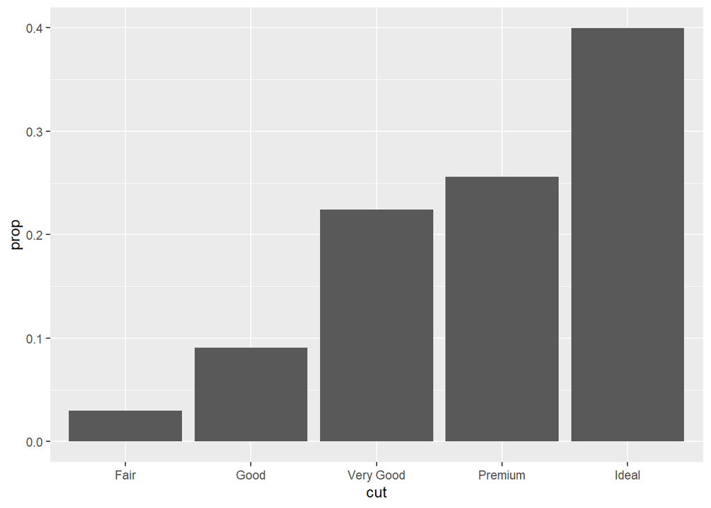

```r
ggplot(data=diamonds) +
  geom_bar(mapping=aes(x=cut, y=stat(prop), group=1))
```

I’m not exactly sure why we are using `group = 1` and why that gives the same thing when we equate it to two. I guess it means that it treats all things inside of this vis as a group and then calculates the proporitons on that. If we remove the group function then the proportion is always equal to one, as it groups by the cut.

It should also be noted that you can also get `geom_col` which requires that you pass whatever you are plotting on the y axis manually.

You can also do more sophisticated things

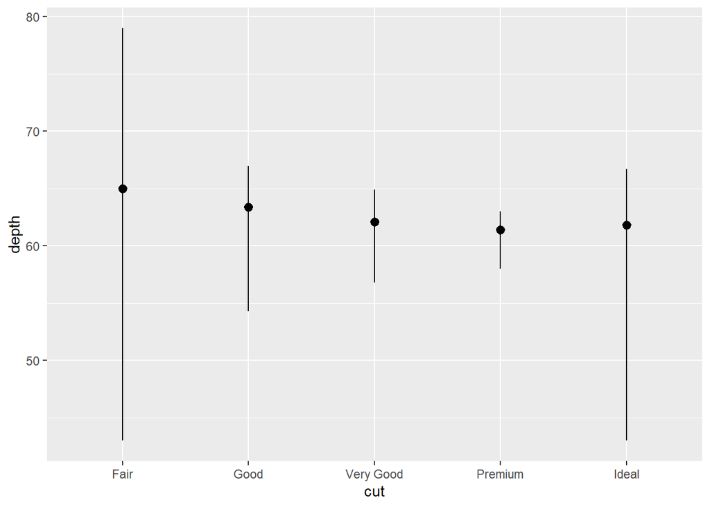

```r
ggplot(data=diamonds) +
  stat_summary(
    mapping=aes(x=cut, y=depth),
    fun.ymin=min,
    fun.ymax=max,
    fun.y=median
  )
```

Note that ggplot has over 20 stats that can be used, each of which is a function. So you can use the `?stat_bin` function in order to have a look at all of them.

## Position Adjustments

You can also create barplots which are unstacked using colour vs fill.

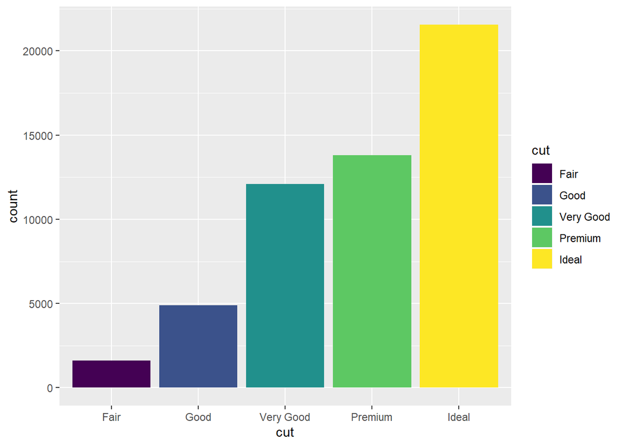

```r
ggplot(data=diamonds) +
  geom_bar(mapping = aes(x=cut, fill=cut))
```

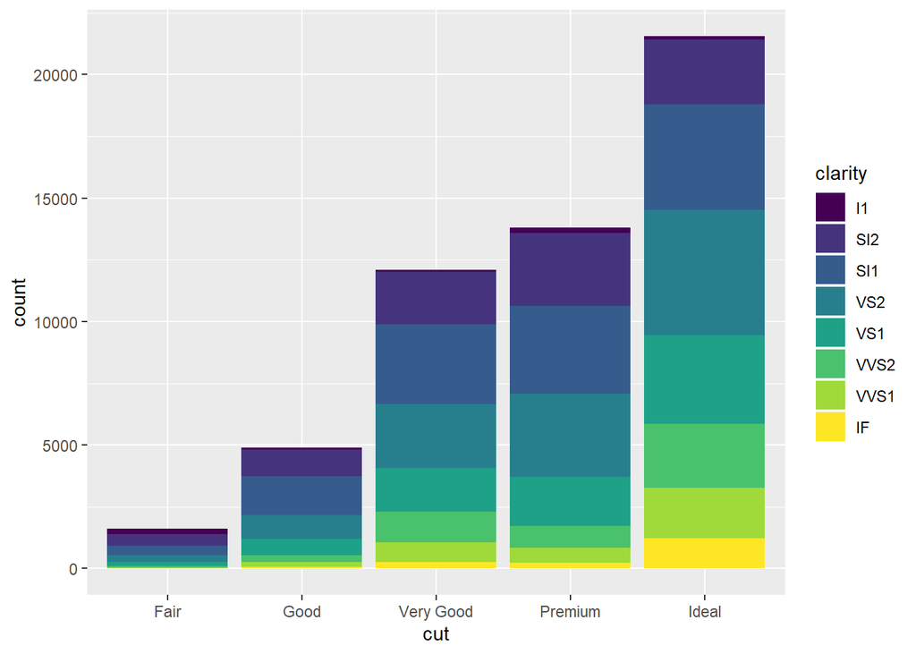

```r
ggplot(data=diamonds) +
  geom_bar(mapping = aes(x=cut, fill=clarity))
```

The differnce here is the `position` parameter. This parameter can be filled with `identity`, `dodge` and `fill`.

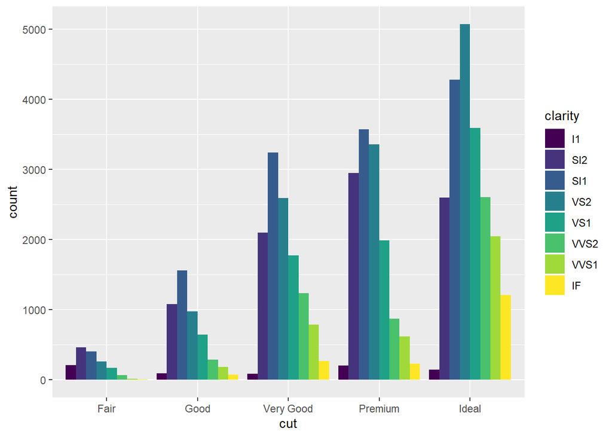

```r
ggplot(data=diamonds) +
  geom_bar(mapping = aes(x=cut, fill=clarity), position = "dodge")
```